# Power Analysis for Multilevel Models With Cross-level Interactions in Intensive Longitudinal Designs

Author

Ginette Lafit

Published

June 8, 2023

## Setting things up

Before we proceed, we need to ensure we have several packages installed and loaded into our `R` session. For the scripts below, we will use the following packages:

- [`tidyverse`](https://CRAN.R-project.org/package=tidyverse)
- [`gridExtra`](https://CRAN.R-project.org/package=gridExtra)
- [`formattable`](https://CRAN.R-project.org/package=formattable)
- [`htmltools`](https://CRAN.R-project.org/package=htmltools)
- [`shiny`](https://CRAN.R-project.org/package=shiny)
- [`DT`](https://CRAN.R-project.org/package=DT)
- [`ggplot2`](https://CRAN.R-project.org/package=ggplot2)
- [`plyr`](https://CRAN.R-project.org/package=plyr)
- [`dplyr`](https://CRAN.R-project.org/package=dplyr)
- [`tidyr`](https://CRAN.R-project.org/package=tidyr)
- [`shinyjs`](https://CRAN.R-project.org/package=shinyjs)
- [`shinythemes`](https://CRAN.R-project.org/package=shinythemes)
- [`viridis`](https://CRAN.R-project.org/package=viridis)
- [`plotly`](https://CRAN.R-project.org/package=plotly)
- [`remotes`](https://CRAN.R-project.org/package=remotes)
- [`nlme`](https://CRAN.R-project.org/package=nlme)
- [`devtools`](https://CRAN.R-project.org/package=devtools)
- [`data.table`](https://CRAN.R-project.org/package=data.table)
- [`MASS`](https://CRAN.R-project.org/package=MASS)
- [`future.apply`](https://CRAN.R-project.org/package=future.apply)

Which we can install in one go as follows:

```r
# Prepare the package list.
packages = c(
    "tidyverse", "gridExtra", "formattable", "htmltools", "shiny",
    "DT", "ggplot2", "plyr", "dplyr", "tidyr", "shinyjs", "shinythemes",
    "viridis", "plotly", "remotes", "nlme", "devtools", "data.table",
    "MASS", "future.apply"
)

# Install packages.
install.packages(packages)
```

**Tip**

At last, we can load the packages into our `R` session:

```r
# Load packages.
library(tidyverse)
library(gridExtra)
library(formattable)
library(htmltools)
library(shiny)
library(DT)
library(ggplot2)
library(plyr)
library(dplyr)
library(tidyr)
library(shinyjs)
library(shinythemes)
library(viridis)
library(plotly)
library(remotes)
library(nlme)
library(devtools)
library(data.table)
library(MASS)
library(future.apply)
```

## Description

The goal of this exercise is to conduct a power analysis to select the number of persons to investigate if depression moderates the relationship between anhedonia and negative affect (NA).

To estimate this research question we will use a multilevel model with a cross-level interaction effect between a level 1 continuous predictor (anhedonia) and level 2 continuos predictor (depression):

$$\begin{multline}
\text{NA}_{it} = \beta_{00} + \beta_{01} \text{Depression}_{i} + \beta_{10} \text{Anhedonia}_{it} +\\
\beta_{01} \text{Depression}_{i}\text{Anhedonia}_{it} +
\nu_{0i} + \nu_{1i} \text{Anhedonia}_{it} + \epsilon_{it}
\end{multline}$$

where $\beta_{00}$ is the fixed intercept, $\beta_{01}$ represents the main effect of *depression*, $\beta_{10}$ is the fixed slope of *anhedonia*, and $\beta_{11}$ represents the cross-level interaction effect between *anhedonia* and *depression*. The cross-level interaction effect assesses whether *depression* moderates the effect of *anhedonia* on NA. The level 1 predictor (i.e., *anhedonia*) is centered within-persons and within-days.

In this model, we account for the serial dependency that characterizes IL designs by assuming that the level 1 errors follow an autoregressive $\text{AR}(1)$ process (see Goldstein et al., 1994):

$$\epsilon_{it} = \rho_\epsilon \epsilon_{it-1} + \varepsilon_{it}$$

where the correlation between two consecutive errors is denoted by $\rho_\epsilon$, and $\varepsilon_{it}$ is a Gaussian error with mean zero and variance $\sigma_\epsilon^2$. Under this model, the variance of the level 1 errors is given by $\sigma_\epsilon^2/(1-\rho_\epsilon^2)$. To guarantee that this model is stationary, the autocorrelation $\rho_\epsilon$ should range between -1 and 1 (Hamilton, 1994).

Between-person differences in the relation between *anhedonia* and NA are captured by including a random intercept $\nu_{0i}$ and random slope $\nu_{1i}$. These random effects are multivariate normal distributed with mean zero and covariance matrix $\Sigma_\nu$:

$$\boldsymbol{\Sigma}_\nu = \begin{bmatrix}
\sigma_{\nu_{0}}^2 & \sigma_{\nu_{01}} \\
\sigma_{\nu_{01}} & \sigma_{\nu_{1}}^2
\end{bmatrix}$$

In this model, it is also assumed that the level 2 random effects and the Level 1 errors are independent.

To investigate if depression moderates the relationship between anhedonia and NA we are going to conduct the following hypothesis test:

$$H_0: \beta_{11} = 0$$

$$H_1: \beta_{11} \neq 0$$

The aim of this exercise is to select the number of participants assuming the number of repeated measurements occasions to $T = 70$.

- Select sample size using the analytic approach, e.g., $N = \{20, 40, ...\}$.
- Compare the results with the ones obtained using the simulation-based approach.

## Determining model parameter values

To obtain the values of the model parameters we will use data from the Leuven clinical study. The code to estimate the multilevel model with cross-level interaction effect is included in the exercise `Multilevel model estimation using the Leuven Clinical Dataset`. The output of the fitted model is:

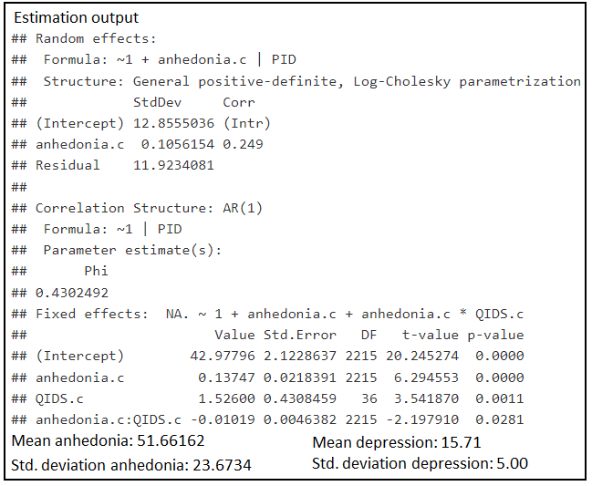

Estimated model parameters

Thus, the values of the model parameter that will be used to conduct the power analysis are:

## Analytical-based power analysis

To conduct the power analysis using the analytic approach we are going to use `ApproxPowerIL`: a `Shiny` application and `R` package to perform power analysis to select the number of persons for multilevel models with auto-correlated errors using asymptotic approximations of the information matrix The repository contains functions used in Lafit et al. (2023). Users can download the app and run locally on their computer by executing the following commands in `R` or `RStudio` at ApproxPowerIL.

```r
# Install the app package from the `GitHub` repository.
remotes::install_github("ginettelafit/ApproxPowerIL", force = TRUE)

# Load package `ApproxPowerIL`.
library(ApproxPowerIL)

# Lunch the app from the `GitHub` gist.
shiny::runGist('302737dc046b89b7f09d15843389161c')
```

### Step 1

**Select the model and set the sample size in the `ApproxPowerIL` application.**

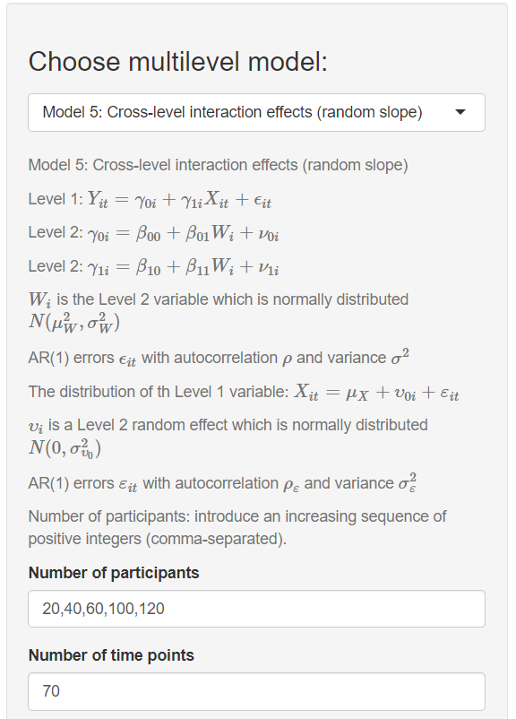

Model and sample size selection in the `Shiny` application

### Step 2

**Set the value of the model parameters in the `ApproxPowerIL` application.**

Use the screenshots below to guide you through the process:

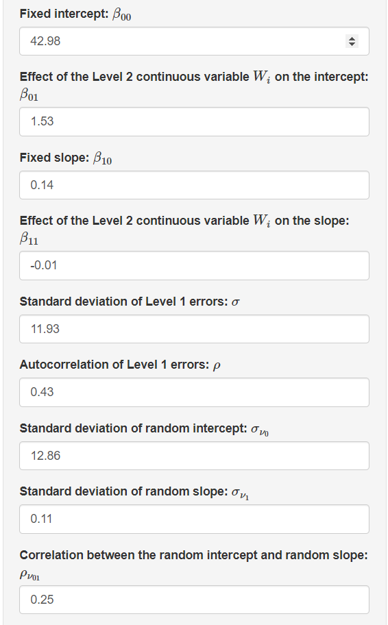

Model parameters specification in the `Shiny` application

And, for the remainder of the parameters:

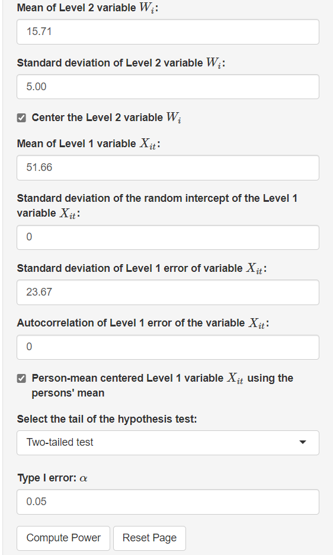

Model parameters specification in the `Shiny` application

### Step 3

**Inspect the results.**

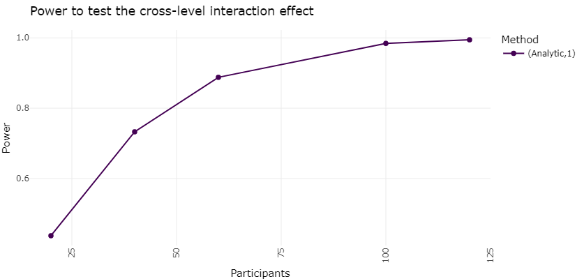

Power curve for the analytical-based approach

## Simulation-based power analysis

To conduct the power analysis using the simulation-based approach we are going to use `PowerAnalysisIL`: a `Shiny` application and `R` package to perform power analysis to select the number of persons for multilevel models using the simulation-based approach.

```r
# Install the app package from the `GitHub` repository.
library(devtools)
devtools::install_github("ginettelafit/PowerAnalysisIL", force = TRUE)

## Load package `PowerAnalysisIL`.
library(PowerAnalysisIL)

# Lunch the app from the `GitHub` gist.
shiny::runGist('6bac9d35c2521cc4fd91ce4b82490236')
```

### Step 1

**Select the model and set the sample size in the `PowerAnalysisIL` application.**

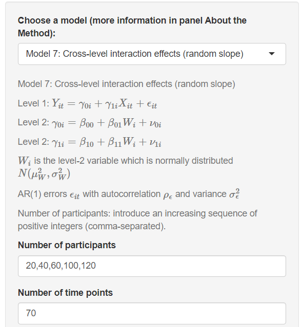

Model and sample size selection in the `Shiny` application

### Step 2

**Set the value of the model parameters in the `PowerAnalysisIL` application.**

Use the screenshots below to guide you through the process:

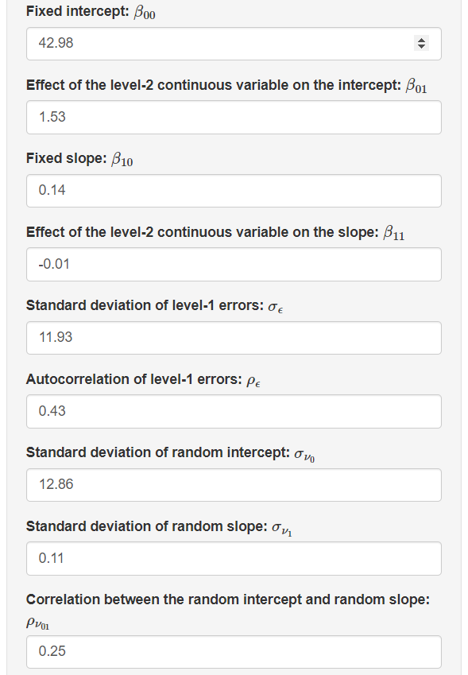

Model parameters specification in the `Shiny` application

And, for the remainder of the parameters:

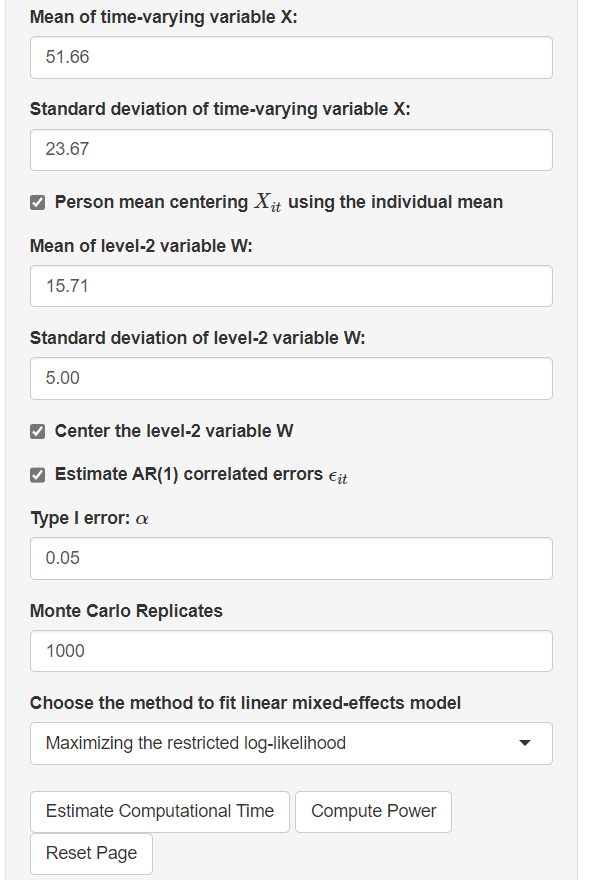

Model parameters specification in the `Shiny` application

### Step 3

**Inspect the results.**

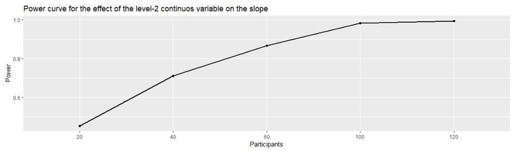

## References

Goldstein, H., Healy, M. J., & Rasbash, J. (1994). Multilevel time series models with applications to repeated measures data. *Statistics in Medicine*, *13*(16), 1643–1655.

Hamilton, J. D. (1994). *Time series analysis* (Vol. 2). Princeton New Jersey.

Lafit, G., Adolf, J. K., Dejonckheere, E., Myin-Germeys, I., Viechtbauer, W., & Ceulemans, E. (2021). Selection of the number of participants in intensive longitudinal studies: A user-friendly shiny app and tutorial for performing power analysis in multilevel regression models that account for temporal dependencies. *Advances in Methods and Practices in Psychological Science*, *4*(1), 2515245920978738.

Lafit, G., Artner, R., & Ceulemans, E. (2023). *Enabling analytical power calculations for multilevel models with autocorrelated errors through deriving and approximating the information matrix*.